# SPSS Tutorial 04

@ Ruhil

2017-08-30

# 1 Hypothesis Tests with Proportions

Much as we can test hypotheses that revolve around a continuous (scale) variable, so can we test hypotheses about proportions – where the variables happen to be nominal or ordinal. For example, is there a difference in the proportion of students who attend private schools versus public schools? Do equal proportions of Washington DC’s residents commute to work by car, walking, biking, or by public transportation? Were men just as likely to survive the Titanic sinking as women?

These tests are easy to run in SPSS. How to run these tests is shown below, depending upon the testing situation.

## 1.1 The One-Proportion Test (Binomial test)

Here you have a single proportion – surviving the Titanic. In SPSS, these can be run with the `Non-parametric Tests >>> One sample …` option under `Analyze`.

### 1.1.1 Video Guide

[figure not shown]

## 1.2 Proportions in Two Groups

If both are ordinal variables then you want to use `Kendall’s` $\tau_{b}$.

### 1.2.1 Video Guide

[figure not shown]

## 1.3 One Multinomial Proportion

If we have more than two categories but a single variable, then we can test our hypotheses about the distribution via `Non-parametric Tests >>> One sample …` option under `Analyze`.

## 1.4 Chi-square Tests of Association

Here we have two categorical variables, each with two or more categories. Using the `Crosstabs…` function we can run the $\chi^2$ test. Note that If any cell has expected frequencies $< 5$ then Fisher’s Exact test must be used. See a wonderful little example of how the test works [here](http://www.quantpsy.org/fisher/fisher.htm). Note also though that people commonly think that Fisher’s Exact test can only be used with $2 \times 2$ tables but there is no such restriction underlying the test per se; it is just that large tables are computationally very demanding.

### 1.4.1 Video Guide

[figure not shown]

# 2 Measuring the Strength of the Association

Note that it makes sense to use the following statistics only if the $H_0$ of no relationship between the two variables has been rejected. This is because these are measures of association that tell you how strong or weak is the relationship between $x$ and $y$

## 2.1 Nominal Variables

1. If you have a $2 \times 2$ table and both variables are Nominal, you can use phi $(\phi)$ or Cramer’s $V$
2. If you have two variables, at least one is Nominal, and one has more than 2 categories, use Cramer’s $V$
3. If you have very large tables ($4 \times 4$ or bigger), then the Contingency Coefficient $(C)$ is recommended
4. If you wish to speak in terms of **dependent** and **independent** variables, then lambda $(\lambda)$ is used with Nominal variables as a *proportional reduction in error (PRE) measure*

## 2.2 Ordinal Variables

If you have Ordinal variables, and don’t care about speaking in terms of **dependent** versus **independent** variables, then:

5. Use gamma $(\gamma)$ as the *proportional reduction in error (PRE) measure* if you have **no tied pairs**
6. If you **have tied pairs** and “square tables”" (i.e., the same number of rows as columns), then use tau-b $(\tau_{b})$
7. If you **have tied pairs** but “no square tables”" (i.e., the number of rows $\neq$ the number of columns), then use tau-c $(\tau_{c})$

If you are keen on speaking in terms of the **dependent variable** (must be the *row variable*) and the **independent variable** (must be the *column variable*), and these are Ordinal variables, then:

8. Use Sommers’ $D$

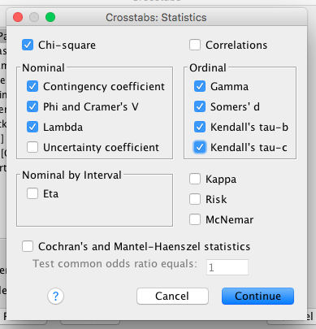

## 2.3 Interpreting the Strength of the Association

| Estimate | Interpretation |
| --- | --- |
| +0.70 or higher | Very strong positive relationship |
| +0.50 to +0.69 | Substantial positive relationship |
| +0.30 to +0.49 | Moderate positive relationship |
| +0.10 to +0.29 | Low positive relationship |
| +0.01 to +0.09 | Negligible positive relationship |
| 0.00 | No relationship |
| -0.01 to -0.09 | Negligible negative relationship |
| -0.10 to -0.29 | Low negative relationship |
| -0.30 to -0.49 | Moderate negative relationship |
| -0.50 to -0.69 | Substantial negative relationship |
| -0.70 or lower | Very strong negative relationship |